# Problem4.4

```r
library(tidyverse)
```

### Initializing the Data

```r
AutoClaims <- read.csv(file.path(str_remove(getwd(), "/Class Notes"), "/Book Data/AutoClaims.csv"))
AutoClaims <- AutoClaims %>%
  mutate(LNPAID = log(PAID))
```

### Problem 4.4

#### a.)

```r
AutoClaimsRega <- lm(LNPAID ~ AGE, data = AutoClaims)

summary(AutoClaimsRega)
```

```
##
## Call:
## lm(formula = LNPAID ~ AGE, data = AutoClaims)
##
## Residuals:
##     Min      1Q  Median      3Q     Max
## -4.7475 -0.6927 -0.0431  0.7101  4.1238
##
## Coefficients:
##              Estimate Std. Error t value Pr(>|t|)
## (Intercept)  7.189060   0.078865  91.157   <2e-16 ***
## AGE         -0.003658   0.001219  -3.001   0.0027 **
## ---
## Signif. codes:  0 '***' 0.001 '**' 0.01 '*' 0.05 '.' 0.1 ' ' 1
##
## Residual standard error: 1.07 on 6771 degrees of freedom
## Multiple R-squared:  0.001329,   Adjusted R-squared:  0.001181
## F-statistic: 9.007 on 1 and 6771 DF,  p-value: 0.002699
```

$$H_0: \beta_{Age} = 0 \\
H_A: \beta_{Age} \not= 0$$
If the minimum p-value from the two-sided t-test for $\beta_{Age}$ is less than $\alpha=0.05$, then we have statistically significant evidence to reject the null hypothesis.

Since the minimum p-value from the two-sided t-test for $\beta_{Age}=0.0027$ is less than $\alpha=0.05$. We reject the null hypothesis. This means there is statistically significant evidence that Age is a good predictor for LNPAID.

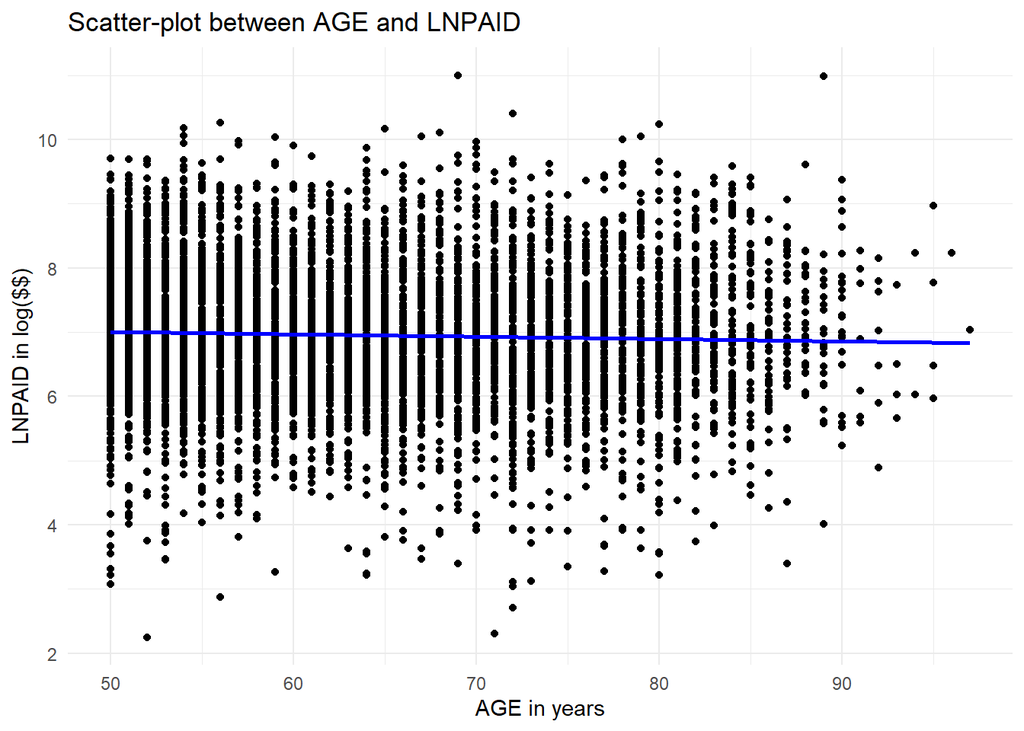

```r
AutoClaims %>%
  ggplot(aes(x=AGE, y=LNPAID)) +
  geom_point() +
  theme_minimal() +
  labs(title= "Scatter-plot between AGE and LNPAID",
       x= "AGE in years",
       y= "LNPAID in log($$)") +
  geom_smooth(method="lm", se=FALSE, col="blue")
```

While AGE is a statistically significant predictor for LNPAID. The goodness of fit between AGE and LNPAID seems very poor based on $\hat\beta_{Age}$ and $R^2$ values. With $R^2=0.001329$ and $\hat\beta_{Age}=-0.003658$. We can say that there is not a strong relationship between AGE and LNPAID.

#### b.)

```r
AutoClaimsRegb <- lm(LNPAID ~ CLASS, data=AutoClaims)

summary(AutoClaimsRegb)
```

```
##
## Call:
## lm(formula = LNPAID ~ CLASS, data = AutoClaims)
##
## Residuals:
##     Min      1Q  Median      3Q     Max
## -4.7002 -0.6912 -0.0437  0.7128  4.1009
##
## Coefficients:
##              Estimate Std. Error t value Pr(>|t|)
## (Intercept)  6.940938   0.039699 174.838   <2e-16 ***
## CLASSC11     0.010564   0.050696   0.208   0.8349
## CLASSC1A    -0.075432   0.128202  -0.588   0.5563
## CLASSC1B     0.057420   0.065380   0.878   0.3798
## CLASSC1C    -0.154707   0.178007  -0.869   0.3848
## CLASSC2     -0.139442   0.142595  -0.978   0.3282
## CLASSC6     -0.015057   0.053217  -0.283   0.7772
## CLASSC7     -0.039775   0.053191  -0.748   0.4546
## CLASSC71     0.012730   0.050887   0.250   0.8025
## CLASSC72     0.241716   0.122626   1.971   0.0487 *
## CLASSC7A     0.122755   0.108174   1.135   0.2565
## CLASSC7B     0.131512   0.056956   2.309   0.0210 *
## CLASSC7C     0.302596   0.125307   2.415   0.0158 *
## CLASSF1      0.062962   0.202561   0.311   0.7559
## CLASSF11    -0.136891   0.173726  -0.788   0.4307
## CLASSF6     -0.030546   0.094148  -0.324   0.7456
## CLASSF7     -0.363874   0.144807  -2.513   0.0120 *
## CLASSF71    -0.005476   0.117810  -0.046   0.9629
## ---
## Signif. codes:  0 '***' 0.001 '**' 0.01 '*' 0.05 '.' 0.1 ' ' 1
##
## Residual standard error: 1.07 on 6755 degrees of freedom
## Multiple R-squared:  0.005048,   Adjusted R-squared:  0.002544
## F-statistic: 2.016 on 17 and 6755 DF,  p-value: 0.00786
```

##### i.)

The point estimate for the LNPAID of claims for the class C7 appears to be $6.940938-0.039775=6.901163$

##### ii.)

```r
-0.039775 + c(-1, 1)*-0.748*0.053191
```

```
## [1]  0.000011868 -0.079561868
```

```r
-0.04 + c(-1,1)*-0.75*0.05
```

```
## [1] -0.0025 -0.0775
```

```r
confint.lm(AutoClaimsRegb, 0.95)
```

[output not shown]

##### iii.)

```r
exp(-0.039775 + c(-1, 1)*-0.748*0.053191)
```

```
## [1] 1.0000119 0.9235209
```

#### c.)

```r
AutoClaimsRegc <- lm(LNPAID ~ AGE+GENDER+STATE+CLASS, data = AutoClaims)

summary(AutoClaimsRegc)
```

```
##
## Call:
## lm(formula = LNPAID ~ AGE + GENDER + STATE + CLASS, data = AutoClaims)
##
## Residuals:
##     Min      1Q  Median      3Q     Max
## -4.7266 -0.6802 -0.0433  0.7072  4.1809
##
## Coefficients:
##                Estimate Std. Error t value Pr(>|t|)
## (Intercept)    6.974923   0.140144  49.770  < 2e-16 ***
## AGE           -0.003021   0.001690  -1.787 0.073914 .
## GENDERM        0.038953   0.026907   1.448 0.147747
## STATESTATE 02  0.098538   0.089280   1.104 0.269765
## STATESTATE 03  0.006302   0.101050   0.062 0.950272
## STATESTATE 04  0.019266   0.093712   0.206 0.837118
## STATESTATE 06  0.283853   0.094105   3.016 0.002568 **
## STATESTATE 07  0.076593   0.106361   0.720 0.471475
## STATESTATE 10  0.181802   0.105448   1.724 0.084739 .
## STATESTATE 11  0.172272   0.365574   0.471 0.637487
## STATESTATE 12  0.388006   0.108333   3.582 0.000344 ***
## STATESTATE 13  0.188491   0.111980   1.683 0.092371 .
## STATESTATE 14  0.068141   0.116720   0.584 0.559373
## STATESTATE 15  0.065570   0.086624   0.757 0.449110
## STATESTATE 17  0.199398   0.096914   2.057 0.039680 *
## CLASSC11       0.055573   0.051695   1.075 0.282410
## CLASSC1A      -0.110591   0.128238  -0.862 0.388506
## CLASSC1B       0.022671   0.066388   0.341 0.732740
## CLASSC1C      -0.160355   0.178056  -0.901 0.367842
## CLASSC2       -0.183935   0.142784  -1.288 0.197719
## CLASSC6        0.057560   0.058767   0.979 0.327395
## CLASSC7       -0.021854   0.054531  -0.401 0.688605
## CLASSC71       0.024622   0.053049   0.464 0.642569
## CLASSC72       0.260057   0.123451   2.107 0.035192 *
## CLASSC7A       0.119315   0.108879   1.096 0.273183
## CLASSC7B       0.124196   0.059098   2.102 0.035634 *
## CLASSC7C       0.299023   0.126300   2.368 0.017934 *
## CLASSF1        0.130054   0.202380   0.643 0.520491
## CLASSF11      -0.058684   0.174394  -0.337 0.736503
## CLASSF6        0.068612   0.098270   0.698 0.485079
## CLASSF7       -0.309974   0.145271  -2.134 0.032898 *
## CLASSF71       0.029459   0.118848   0.248 0.804239
## ---
## Signif. codes:  0 '***' 0.001 '**' 0.01 '*' 0.05 '.' 0.1 ' ' 1
##
## Residual standard error: 1.066 on 6741 degrees of freedom
## Multiple R-squared:  0.01365,    Adjusted R-squared:  0.009113
## F-statistic: 3.009 on 31 and 6741 DF,  p-value: 4.354e-08
```

```r
anova(AutoClaimsRegc)
```

```
## Analysis of Variance Table
##
## Response: LNPAID
##             Df Sum Sq Mean Sq F value    Pr(>F)
## AGE          1   10.3 10.3202  9.0795  0.002595 **
## GENDER       1    2.1  2.0825  1.8321  0.175923
## STATE       12   59.0  4.9197  4.3283 6.786e-07 ***
## CLASS       17   34.6  2.0348  1.7902  0.023610 *
## Residuals 6741 7662.2  1.1367
## ---
## Signif. codes:  0 '***' 0.001 '**' 0.01 '*' 0.05 '.' 0.1 ' ' 1
```

##### i.)

$$H_0: \beta_{Gender}=0 \\
H_A: \beta_{Gender}\not=0$$
If the F-test of Gender is less than $\alpha=0.05$, then we reject the null hypothesis

Since the F-test yielded a p-value of 0.1759 and is greater than $\alpha=0.05$. We fail to reject the null hypothesis. This means there is no statistically significant evidence that Gender is a good predictor.

##### ii.)

$$H_0: \beta_{CLASS}=0 \\
H_A: \beta_{CLASS}\not=0$$

If the F-test of Class is less than $\alpha=0.05$, then we reject the null hypothesis

Since the F-test yielded a p-value of 0.0236 and is less than $\alpha=0.05$. We reject the null hypothesis. This means there is statistically significant evidence that Class is a good predictor.

##### iii.)

```r
exp(6.974923-0.003021*60+0.038953+0.098538-0.021854)
```

```
## [1] 1001.546
```

##### iv.)

The coefficient for someone designated in the class C7 is -0.021854. This means that holding all other variables constant, someone designated the class C7 pays -0.021854 log dollars less than someone designated the class C1.